# intpoints

Lorenzo Busetto

19 February 2018

## The problem

Last week, I replied to this interesting question posted by posted by @Tim_K over stackoverflow. He was seeking efficient solutions to identify all points falling within a maximum distance of xx meters with respect to each single point in the dataset.

If you have a look at the thread, you will see that a simple solution based on creating a “buffered” polygon dataset beforehand and then intersecting it with the original points is quite fast for “reasonably sized” datasets, thanks to `sf` spatial indexing capabilities which reduce the number of the required comparisons to be done (See http://r-spatial.org/r/2017/06/22/spatial-index.html). In practice, something like this:

```r
# create test data: 50000 uniformly distributed points on a "square" of 100000
# metres
maxdist <- 500
pts     <- data.frame(x = runif(50000, 0, 100000),
                      y = runif(50000, 0, 100000),
                      id = 1:50000) %>%
  sf::st_as_sf(coords = c("x", "y"))
# create buffered polygons
pts_buf <- sf::st_buffer(pts, maxdist)
# Find points within 500 meters wrt each point
int <- sf::st_intersects(pts_buf, pts)
int
```

```
## Sparse geometry binary predicate list of length 50000, where the predicate was `intersects'
## first 10 elements:
##  1: 1, 8816
##  2: 2, 10662, 30775
##  3: 3, 986, 12558, 14217, 31216
##  4: 4, 10276, 11838, 16370
##  5: 5, 2816, 12412, 29241, 38398, 40021
##  6: 6, 29180, 35149, 37082
##  7: 7, 22720, 23178, 23684, 47983
##  8: 8, 7030, 20393, 24263, 43963
##  9: 9, 1352, 15286, 35819, 36489, 44701
##  10: 10, 11043, 43833
```

However, this starts to have problems over really large datasets, because the total number of comparisons to be done still rapidly increase besides the use of spatial indexes. A test done by changing the number of points in the above example in the range 25000 - 475000 shows for example this kind of behavior, for two different values of `maxdist` (500 and 2000 m):

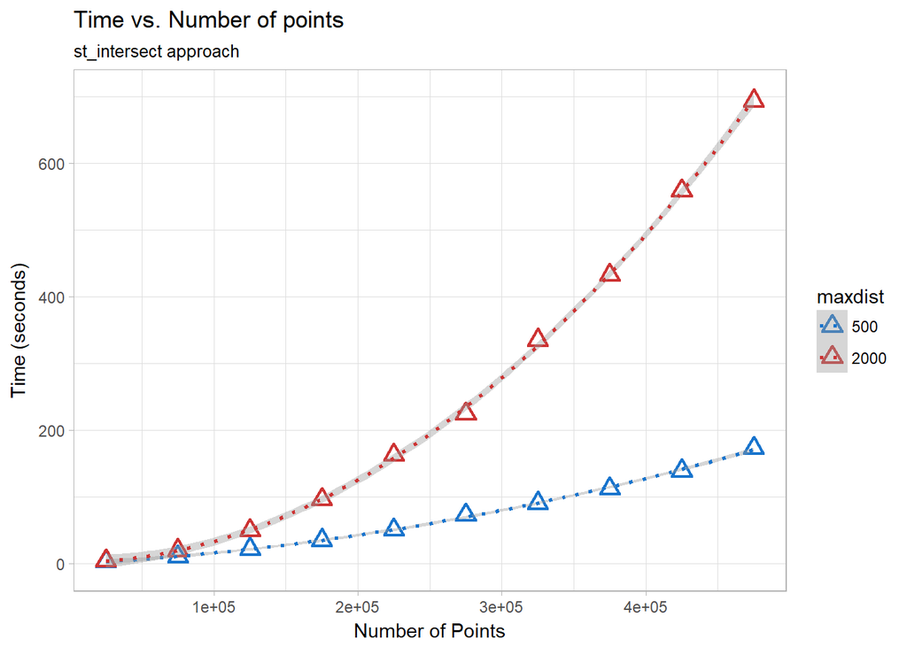

My suggestion to the OP was therefore to **“split” the points in chunks** based on the x-coordinate and then work on a per-split basis, eventually assigning each chunk to a different core within a parallellized cycle.

In the end, I got curious and decided to give it a go **to see what kind of performance improvement it was possible to obtain** with that kind of approach. You can find results of some tests below.

## A (possible) solution: Speeding up computation by combining data.table and sf_intersect

The idea here is to use a **simple divide-and-conquer approach**.

We first **split the total spatial extent** of the dataset in a certain number of regular quadrants. We then cycle over the quadrants and at each cycle we:

1. Extract the **points contained into the quadrant** and apply the buffer to them;
2. Extract the **points contained in a slightly larger area**, computed by expanding the quadrant by an amount equal to the maximum distance for which we want to identify the “neighbors”;
3. **Compute and save the intersection** between the buffered points and the points contained in the “expanded” quadrant

Provided that the subsetting operations do not introduce an excessive overhead (i.e., they are fast enough…) this should provide a performance boost, because it **should consistently reduce the total number of comparisons** to be done.

Now, every “R” expert will tell you that if you need to perform fast subsetting over large datasets the way to go is to use **properly indexed** `data.tables`, which provide lightning-speed subsetting capabilities.

So, let’s see **how we could code this** in a functions:

```r
points_in_distance <- function(in_pts,
                               maxdist,
                               ncuts = 10) {

  require(data.table)
  require(sf)
  # convert points to data.table and create a unique identifier
  pts <-  data.table(in_pts)
  pts <- pts[, or_id := 1:dim(in_pts)[1]]

  # divide the extent in quadrants in ncuts*ncuts quadrants and assign each
  # point to a quadrant, then create the index over "x" to speed-up
  # the subsetting
  range_x  <- range(pts$x)
  limits_x <-(range_x[1] + (0:ncuts)*(range_x[2] - range_x[1])/ncuts)
  range_y  <- range(pts$y)
  limits_y <- range_y[1] + (0:ncuts)*(range_y[2] - range_y[1])/ncuts
  pts[, `:=`(xcut =  as.integer(cut(x, ncuts, labels = 1:ncuts)),
             ycut = as.integer(cut(y, ncuts, labels = 1:ncuts)))]  %>%
    setkey(x)

  results <- list()
  count <- 0
  # start cycling over quadrants
  for (cutx in unique(pts$xcut)) {

    # get the points included in a x-slice extended by `dist`, and build
    # an index over y to speed-up subsetting in the inner cycle
    min_x_comp    <- ifelse(cutx == 1,
                            limits_x[cutx],
                            (limits_x[cutx] - maxdist))
    max_x_comp    <- ifelse(cutx == ncuts,
                            limits_x[cutx + 1],
                            (limits_x[cutx + 1] + maxdist))
    subpts_x <- pts[x >= min_x_comp & x < max_x_comp] %>%
      setkey(y)

    for (cuty in unique(pts$ycut)) {
      count <- count + 1

      # subset over subpts_x to find the final set of points needed for the
      # comparisons
      min_y_comp  <- ifelse(cuty == 1,
                            limits_y[cuty],
                            (limits_x[cuty] - maxdist))
      max_y_comp  <- ifelse(cuty == ncuts,
                            limits_x[cuty + 1],
                            (limits_x[cuty + 1] + maxdist))
      subpts_comp <- subpts_x[y >= min_y_comp & y < max_y_comp]

      # subset over subpts_comp to get the points included in a x/y chunk,
      # which "neighbours" we want to find. Then buffer them.
      subpts_buf <- subpts_comp[ycut == cuty & xcut == cutx] %>%
        sf::st_as_sf() %>%
        st_buffer(maxdist)

      # retransform to sf since data.tables lost the geometric attrributes
      subpts_comp <- sf::st_as_sf(subpts_comp)

      # compute the intersection and save results in a element of "results".
      # For each point, save its "or_id" and the "or_ids" of the points within "dist"
      inters <- sf::st_intersects(subpts_buf, subpts_comp)

      # save results
      results[[count]] <- data.table(
        id = subpts_buf$or_id,
        int_ids = lapply(inters, FUN = function(x) subpts_comp$or_id[x]))
    }
  }
  data.table::rbindlist(results)
}
```

The function takes as input a **points `sf` object**, a **target distance** and a **number of “cuts”** to use to divide the extent in quadrants, and provides in output a data frame in which, for each original point, the “ids” of the points within `maxdist` are reported **in the `int_ids` list column**.

Now, let’s see if it works:

```r
pts <- data.frame(x = runif(20000, 0, 100000),
                  y = runif(20000, 0, 100000),
                  id = 1:20000) %>%
  st_as_sf(coords = c("x", "y"), remove = FALSE)
maxdist <- 2000
out <- points_in_distance(pts, maxdist = maxdist, ncut = 10)
out
```

```
##           id                              int_ids
##     1:   351  2057, 7770, 1421, 8155,12979,17025,
##     2: 15555 12033,13094, 7039,17025,15555, 1877,
##     3:  1877  2057, 1421, 7039,17025,  351,15555,
##     4: 12564  2057, 7770, 1421, 8155,12979,17025,
##     5: 14021  3552, 9630, 3808,19323,14173, 3605,
##    ---
## 19995:  5947 19584, 7954,17881,  529,14991,15177,
## 19996: 16865 19994, 9331, 8827,15090, 7490,   10,
## 19997:   822  8827,   10,13439,15481, 9336,12930,
## 19998:  1568 14488,13439, 9336,12930,14553,18438,
## 19999:  7354  7954,17881,  529,14991,15177,10235,
```

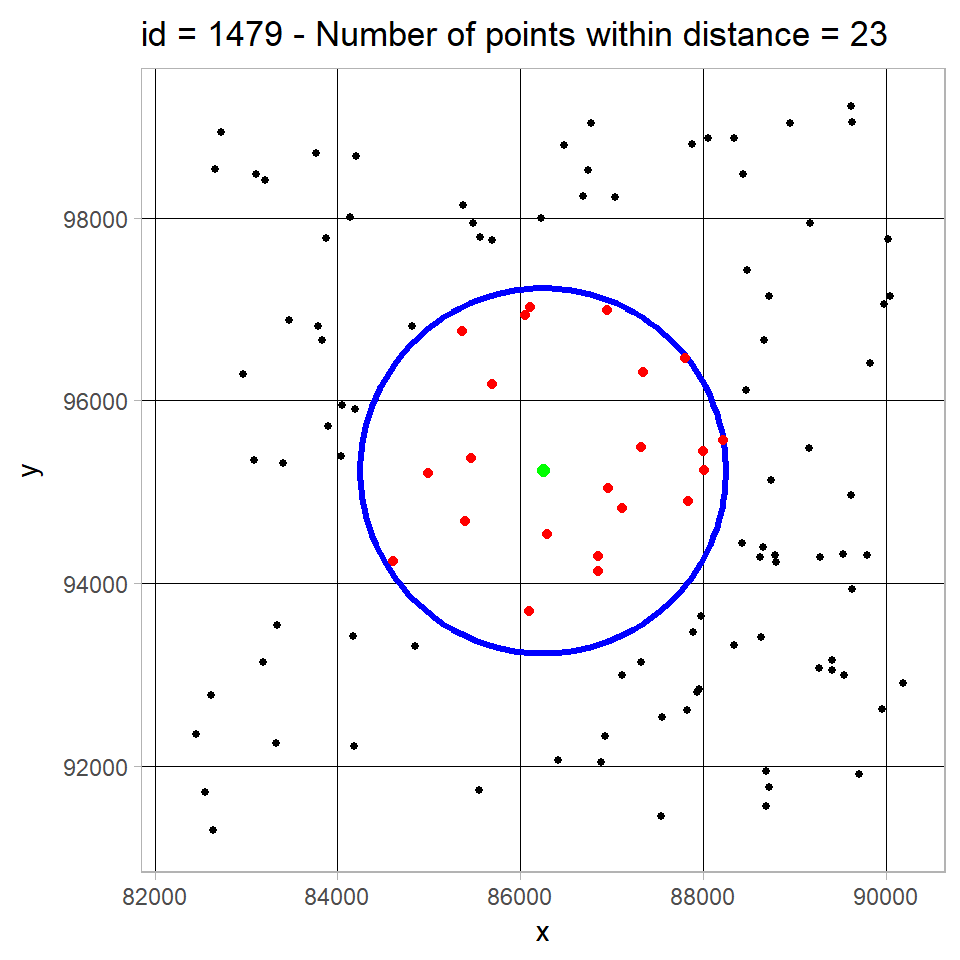

```r
# get a random point
sel_id  <- sample(pts$id,1)
pt_sel  <- pts[sel_id, ]
pt_buff <- pt_sel %>%  sf::st_buffer(maxdist)
# get ids of points within maxdist
id_inters <- unlist(out[id == sel_id, ]$int_ids)
pt_inters <- pts[id_inters,]

#plot results
ggplot(pt_buff)  + theme_light() +
  geom_point(data = pts, aes(x = x, y = y), size = 1) +
  geom_sf(col = "blue", size = 1.2, fill = "transparent") +
  geom_sf(data = pt_inters, col = "red", size = 1.5) +
  geom_point(data = pt_sel, aes(x = x, y = y), size = 2, col = "green") +
  xlim(st_bbox(pt_buff)[1] - maxdist, st_bbox(pt_buff)[3] + maxdist) +
  ylim(st_bbox(pt_buff)[2] - maxdist, st_bbox(pt_buff)[4] + maxdist) +
  ggtitle(paste0("id = ", sel_id, " - Number of points within distance = ", length(id_inters)))
```

**So far, so good**. Now, let’s do the same exercise with varying number of points to see how it behaves in term of speed:

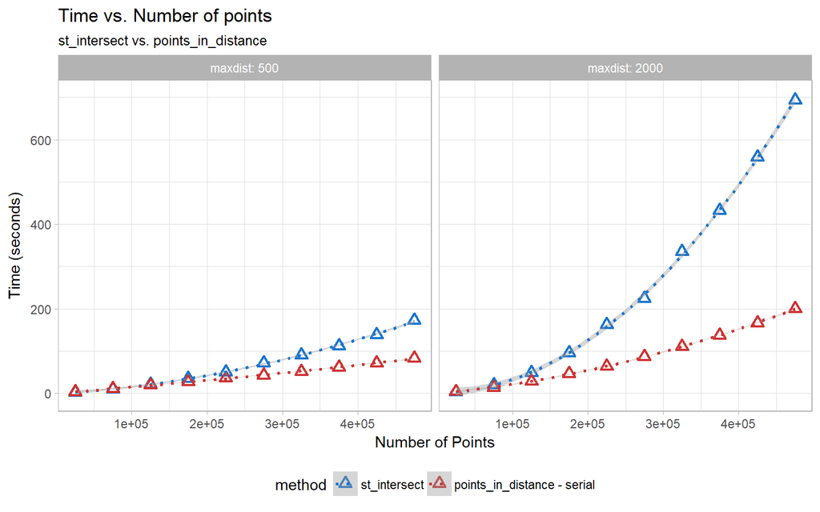

Already not bad! In particular for the `maxdist = 2000` case, we get a quite large speed improvement!

However, a nice thing about the `points_in_distance` approach is that **it is easily parallelizable**. All is needed is to change some lines of the function so that the outer loop over the `x` “chunks” exploits a parallel backend of some kind. (You can find an example exploiting `foreach` in [this gist](https://gist.github.com/lbusett/247dc9b0b6bed04ac1b45c03999be348))

On a not-particularly-fast PC, using a 6-cores parallelization leads to this:

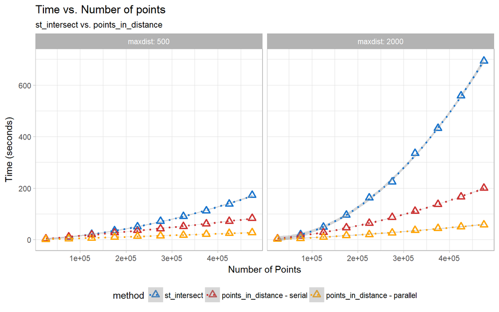

**Looking good!** Some more skilled programmer could probably squeeze out even more speed from it by some additional `data.table` magic, but the improvement is very noticeable.

In terms of execution time, extrapolating again to the **“infamous” 12 Million points dataset,** this would be what we get:

| Method | Maxdist | Expected completion time (hours) |
| --- | --- | --- |
| st_intersect | 500 | 15.00 |
| points_in_distance - serial | 500 | 2.50 |
| points_in_distance - parallel | 500 | 0.57 |
| st_intersect | 2000 | 85.00 |
| points_in_distance - serial | 2000 | 15.20 |
| points_in_distance - parallel | 2000 | 3.18 |

So, we get **a 5-6X speed improvement** already on the “serial” implementation, and **another 5X** thanks to parallelization over 6 cores! On the `maxdist = 2000` case, this means going **from more than 3 days to about 3 hours**. And if we had more cores and RAM to throw at it, it would finish in minutes!

Pretty nice!

## Final Notes

- The timings shown here are merely indicative, and related to the particular test-dataset we built. On a less uniformly distributed dataset I would expect a lower speed improvement.
- Some time is “wasted” because `sf` does not (yet) extend `data.tables`, making it necessary to recreate `sf` objects from the `data.table` subsets.
- The parallel implementation is quick-and-dirty, and it is a bit of a memory-hog! Be careful before throwing at it 25 processors!
- Speed is influenced in a non-trivial way by the number of “cuts” used to subdivide the spatial extent. There may be a sweet-spot related to points distribution and maxdist allowing reaching maximum speed.
- A similar approach for parallelization could exploit repeatedly “cropping” the original `sf` points object over the extent of the chunk/extended chunk. The `data.table` approach seems however to be faster.

Hope you liked this (rather long) post!